# Project 2

Lucas Rodriguez

2024-11-13

## 1. Introduction

```r
InitialData <- read.csv("Project2CleanedDataset.csv")
# forgot to remove this variable during the inital cleaning
# process
InitialData <- select(InitialData, -skipped)
# also needed to change the timestamp to US Central time
# (In UTC by default)
InitialData <- mutate(InitialData, ts = with_tz(ymd_hms(ts),
    "America/Chicago"))
```

[figure not shown]

The dataset above is the extended history of my spotify account. This data can be requested by a spotify subscriber with the [following link](https://www.spotify.com/us/account/privacy/). I chose the following dataset because I planned on manipulating this dataset as a passion project as I was always fascinated by spotify wrapped and wanted to create an all-time one, not one limited to a year’s time frame that is only viewable for a month.

## 2. Data Preperation

I recieved an email with a zip file approximately 3 weeks after I requested the extended streaming history from spotify. The zip file contained around 15 .JSON files, that contained every song or podcast I had ever streamed on spotify, up until the date that the files were delivered to me. I attatched the file in the repo, but I used the ‘rjson’ and the ‘jsonlite’ packages to transform the JSON files into dataframes, then merged the dataframes and removed excess columns to create the dataset seen above. Manipulating .JSON files was an unique experience for me, something that took extensive research to find out how to best manipulate them to create a dataset for this project

## 3. Variable description

```r
CleanedData <- as.tibble(InitialData)
CleanedData <- rename(CleanedData, Number = X)
CleanedData <- rename(CleanedData, Timestamp = ts)
CleanedData <- rename(CleanedData, TrackName = master_metadata_track_name)
CleanedData <- rename(CleanedData, ArtistName = master_metadata_album_artist_name)
CleanedData <- rename(CleanedData, AlbumName = master_metadata_album_album_name)
CleanedData <- rename(CleanedData, TrackID = spotify_track_uri)
VariableNames = c("Timestamp", "ms_played", "reason_start", "reason_end",
    "shuffle", "offline")
VariableType = c("Quantitative", "Quantitative", "Qualitative",
    "Qualitative", "Qualitative", "Qualitative")
VariableDesc = c("The date and time when played", "The length of the play session (ms)",
    "How the song started playing", "How the song stopped playing",
    "If the song appeared on a shuffle", "If the song was played offline or online")
TableData <- data.frame(rbind(VariableType, VariableDesc))
colnames(TableData) <- VariableNames
kable_classic(kbl(TableData))
```

|  | Timestamp | ms_played | reason_start | reason_end | shuffle | offline |
| --- | --- | --- | --- | --- | --- | --- |
| VariableType | Quantitative | Quantitative | Qualitative | Qualitative | Qualitative | Qualitative |
| VariableDesc | The date and time when played | The length of the play session (ms) | How the song started playing | How the song stopped playing | If the song appeared on a shuffle | If the song was played offline or online |

## 4. Univariate Analysis

#### Variable 1: ms_played

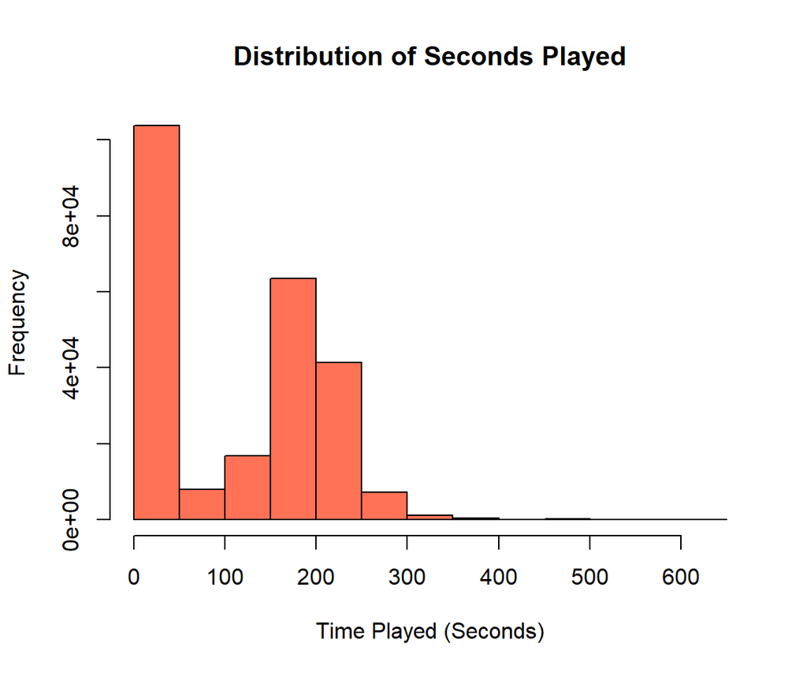

```r
# Removed all non songs from the distribution
CleanedData1 <- filter(CleanedData, is.na(TrackName) == FALSE)

CleanedData1 <- filter(CleanedData1, ms_played <= 650000)
# set the limits for the longest full song I have played
# (All Too Well 10 Minute Version), any datapoints with a
# longer playtime were errors in data

CleanedData1 <- mutate(CleanedData1, SecondsPlayed = ms_played/1000)

hist(CleanedData1$SecondsPlayed, col = "coral1", main = "Distribution of Seconds Played",
    xlab = "Time Played (Seconds)")
```

#### Variable 2: reason_start

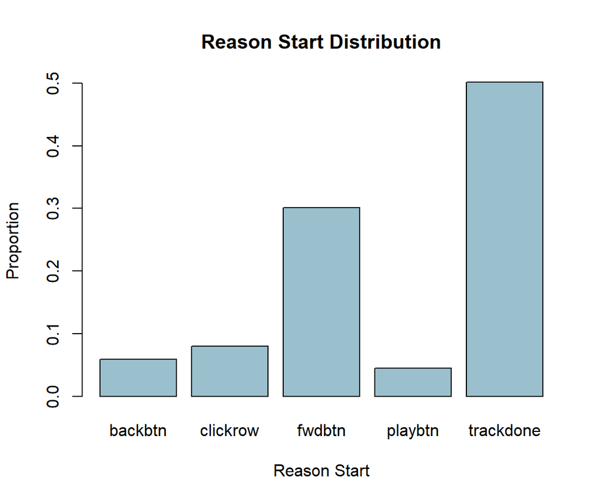

```r
V2Table <- prop.table(table(CleanedData1$reason_start))
# removing datapoints with less than 1% of the proportion
V2Table <- V2Table[(V2Table/sum(V2Table)) >= 0.01]
barplot(V2Table, col = "lightblue3", ylab = "Proportion", xlab = "Reason Start",
    main = "Reason Start Distribution")
```

The above graph showcases the distribution between reasons a track starts playing. With 51%, trackdone has slightly over half of the reason start variables, with fwdbtn having 30% percent of the outcomes. The 3 other notable outcomes, ‘backbtn’, ‘clickrow’, and ‘playbtn’, all had less than 10% of the outcomes. All other outcomes had less than 1%, and were removed from the bar plot in the coding phase to improve visibility

#### Variable 3: reason_end

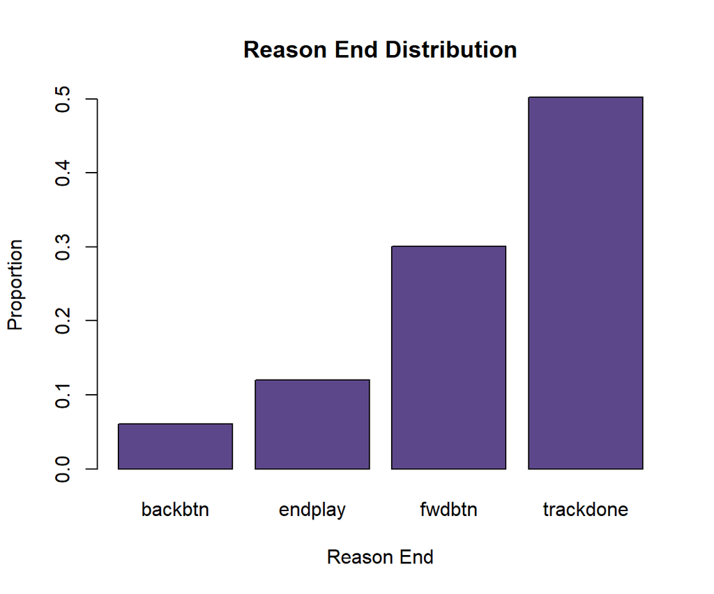

```r
V3Table <- prop.table(table(CleanedData1$reason_end))
# removing datapoints with less than 1% of the proportion
V3Table <- V3Table[(V3Table/sum(V3Table)) >= 0.01]
barplot(V3Table, col = "mediumpurple4", xlab = "Reason End",
    ylab = "Proportion", main = "Reason End Distribution")
```

As expected, the Reason End distribution has a very similar theme, with the trackdone (51%) and fwdbtn (31%) having nearly identical percentages as the Reason Start graph, as when a track starts when a previous track finished (trackdone), they would both be counted with ‘trackdone’ in reason start and reason end respectively. the same logic applies to fwdbtn. Endplay does have over 10% of the outcomes, unlike any of the tertiary outcomes in reason start.

#### Variable 4: Shuffle

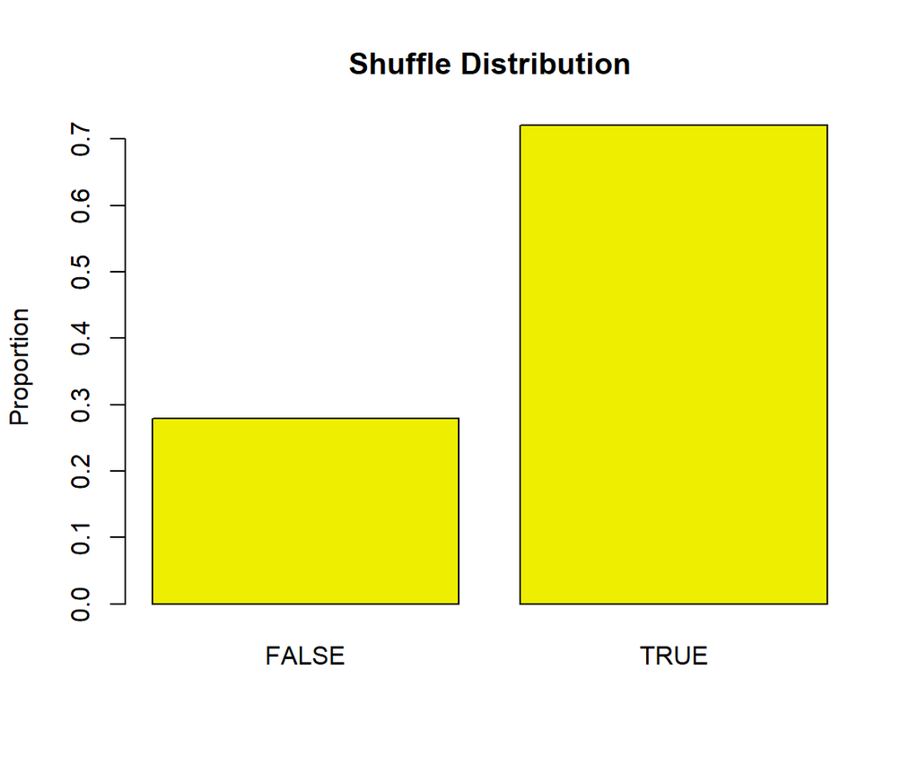

```r
V4Table <- prop.table(table(CleanedData1$shuffle))
barplot(V4Table, col = "yellow2", ylab = "Proportion", main = "Shuffle Distribution")
```

The graph above showcases that 72% of the tracks appeared due to shuffle being enabled, as opposed to 28% appearing without shuffle

#### Variable 5: Offline

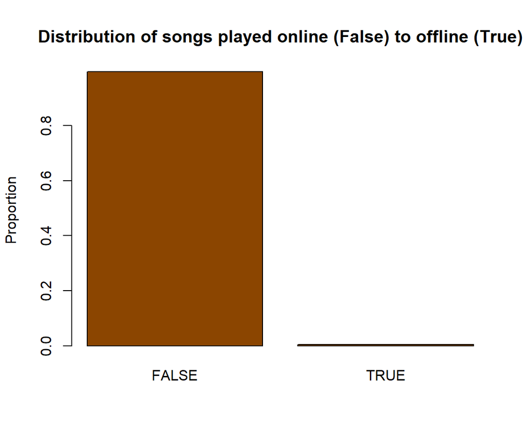

```r
V5Table <- prop.table(table(CleanedData1$offline))
barplot(V5Table, ylab = "Proportion", main = "Distribution of songs played online (False) to offline (True)",
    col = "darkorange4")
```

A remarkable 100% of tracks were recorded with internet or cellular connection, which is explanatory as the only instances where I would have play tracks offline would be when I was in the middle of nowhere or on an airplane, which would be a very small percentage (0% exactly) of tracks played.

#### Variable 6: Date

###### Year

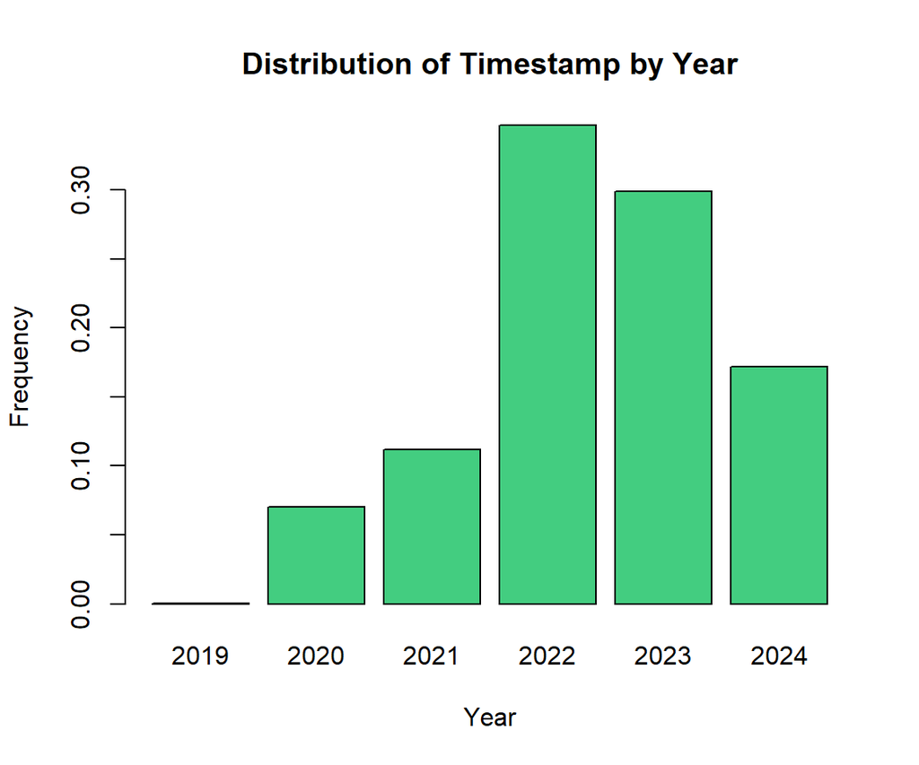

```r
CleanedData3Y <- mutate(CleanedData1, Year = year(CleanedData1$Timestamp))
V6Table1 <- prop.table(table(CleanedData3Y$Year))
barplot(V6Table1, col = "seagreen3", xlab = "Year", ylab = "Frequency",
    main = "Distribution of Timestamp by Year")
```

###### Month

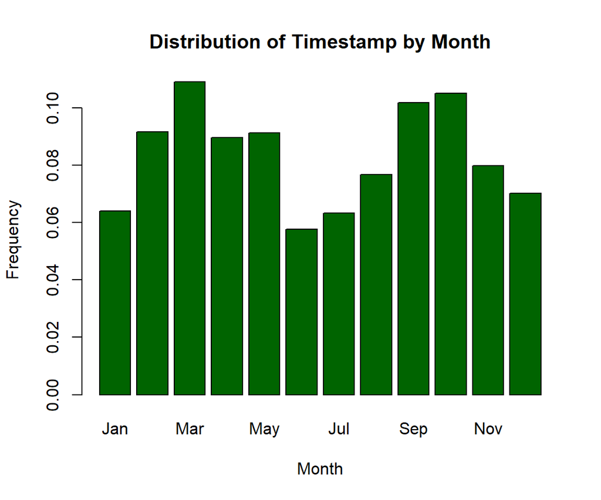

```r
# distributed by month
CleanedData3M <- mutate(CleanedData1, Month = month(CleanedData1$Timestamp,
    label = TRUE, abbr = TRUE))
V6Table2 <- prop.table(table(CleanedData3M$Month))
bpV6.2 <- barplot(V6Table2, col = "darkgreen", xlab = "Month",
    ylab = "Frequency", main = "Distribution of Timestamp by Month",
    names.arg = names(V6Table2))
```

The monthly distribution showcases that March (11%), September (10%), and October(11%) have the largest percentages, with the summer months (June (6%), July (6%), August (8%)) and the holiday season (November (8%), December (7%), January (6%) having consistently lower streaming numbers than other months.

## 5. Bivariate Analysis

#### Graph 1: Seconds Played vs Year

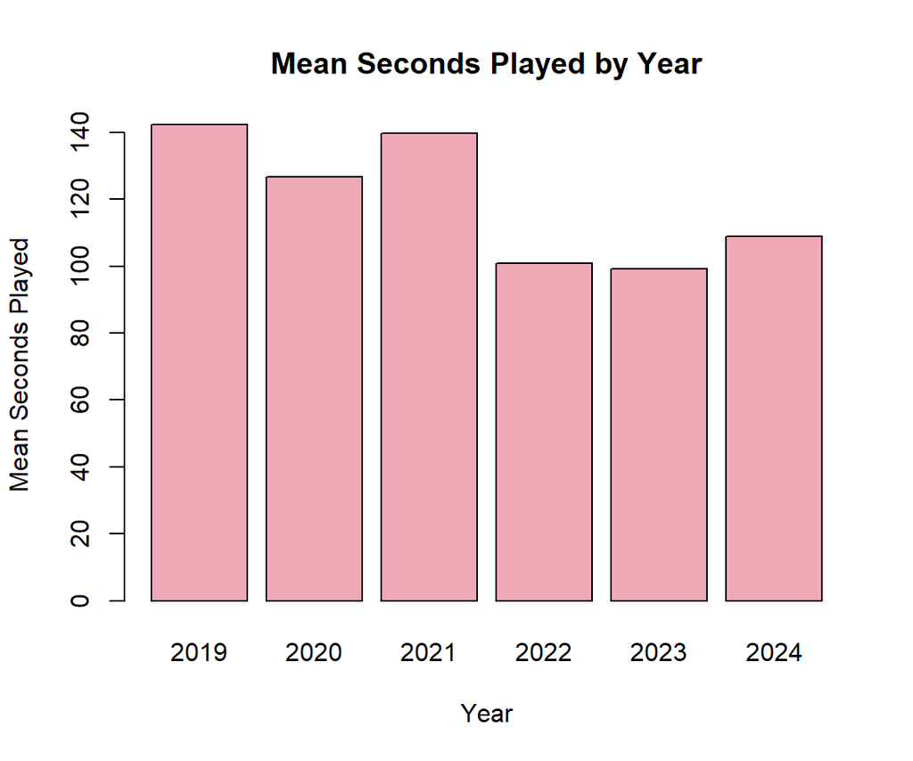

```r
BV1 <- tapply(CleanedData3Y$SecondsPlayed, CleanedData3Y$Year,
    mean)
barplot(BV1, col = "pink2", main = "Mean Seconds Played by Year",
    xlab = "Year", ylab = "Mean Seconds Played")
```

The above graph showcases the average length of a play session in seconds by year. Interestingly, 2019 leads with a mean seconds played of 142.35, followed by 2021 with a mean of 139.74 seconds played, and 2020 with a mean of 126.77 seconds played. Interestingly, these are the 3 years with the lowest sum of play sessions (See graph in Variable 6, Year).

#### Graph 2: Year vs Reason Start

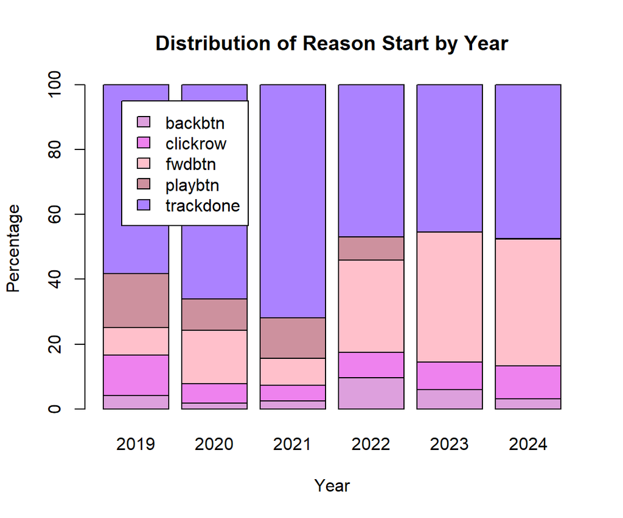

```r
# only including the 5 outcomes in the reason start graph
BV2Data <- filter(CleanedData3Y, reason_start == c("trackdone",
    "fwdbtn", "backbtn", "playbtn", "clickrow"))

BV2Table <- prop.table(table(BV2Data$reason_start, BV2Data$Year),
    margin = 2)
BV2Table <- BV2Table * 100

barplot(BV2Table, col = c("plum", "violet", "pink", "pink3",
    "mediumpurple1"), main = "Distribution of Reason Start by Year",
    xlab = "Year", ylab = "Percentage")

legend("topleft", legend = rownames(BV2Table), cex = 1, fill = c("plum",
    "violet", "pink", "pink3", "mediumpurple1"), xpd = TRUE,
    inset = c(0.075, 0.05))
```

#### Graph 3: Month vs Seconds Played

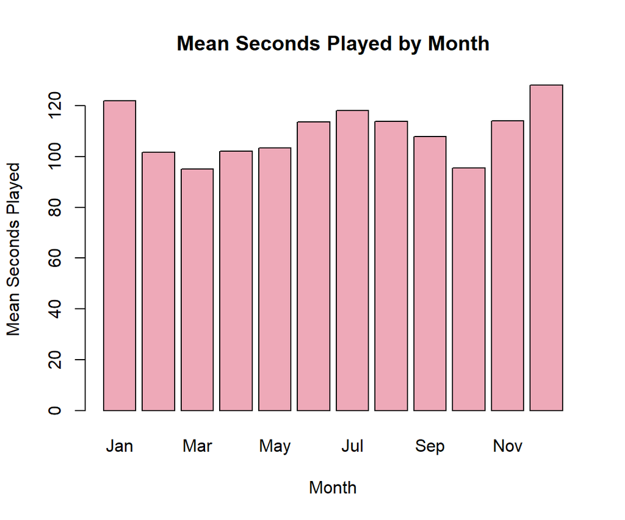

```r
BV3 <- tapply(CleanedData3M$SecondsPlayed, CleanedData3M$Month,
    mean)
barplot(BV3, col = "pink2", main = "Mean Seconds Played by Month",
    xlab = "Month", ylab = "Mean Seconds Played")
```

This graph shares similar patterns with Graph 1, where the months that showed lower streaming numbers as seen in the Variable 6: Month graph experienced higher mean seconds played. The holiday months (November, December, January) and summer months (June, July, August) defined in the inital Months graph have a mean of 121.39 and 115.14 respectively, while the other 6 months have a mean of 100.94, noticeably lower.

#### Graph 4: Months vs Reason Start

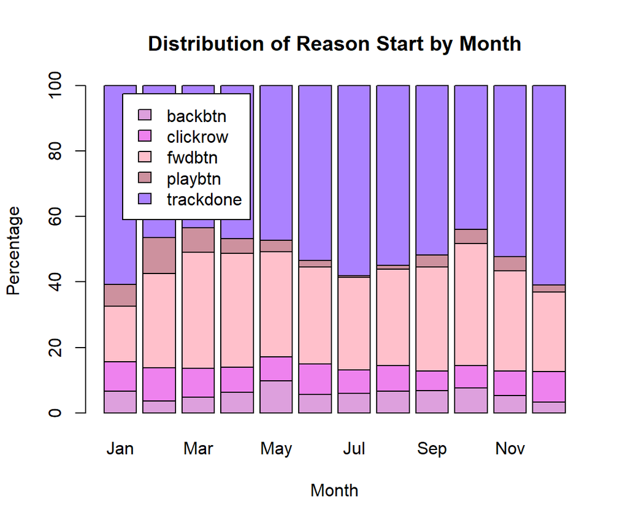

```r
# only including the 5 outcomes in the reason start graph
BV4Data <- filter(CleanedData3M, reason_start == c("trackdone",
    "fwdbtn", "backbtn", "playbtn", "clickrow"))

BV4Table <- prop.table(table(BV4Data$reason_start, BV4Data$Month),
    margin = 2)
BV4Table <- BV4Table * 100

barplot(BV4Table, col = c("plum", "violet", "pink", "pink3",
    "mediumpurple1"), main = "Distribution of Reason Start by Month",
    xlab = "Month", ylab = "Percentage")

legend("topleft", legend = rownames(BV4Table), cex = 1, fill = c("plum",
    "violet", "pink", "pink3", "mediumpurple1"), xpd = TRUE,
    inset = c(0.075, 0.025))
```

## Conclusion

Overall, I learned a lot about my listening habits throughout this project. The exploration of variables focused on the timestamp, seconds played and reason start variables mainly, with brief univariate analyses of other variables in the dataset. The overall takeaways are that time based variables with a lower quantity of datapoints experienced higher mean seconds played and higher percentages of ‘trackdone’ outputs for the reason start variable. The reason start and reason ends variable had very similar distributions as seen in the univariate analysis, so I stuck to reason start for the bivariate comparisons. Likewise, the months with a larger quantity of datapoints had a lower mean seconds played and a larger proportion of the ‘fwdbtn’ reason start which correlates with skipped songs. Additionally, the correlation between larger mean seconds played and larger proportions of ‘trackdone’ reason start were also found. Viceversa is also true, which makes sense as the more songs that are skipped, the more songs that register close to 0 seconds played, which brings down the average.

#### References

Image: https://newsroom.spotify.com/media-kit/logo-and-brand-assets/ GitHub Repository: https://github.com/ldchump/Project2.git